# Welcome to Statistics @ ISU!

2023-06-08

## Statistics @ ISU

## Campus Location

[figure not shown]

## [Snedecor Hall](https://www.fpm.iastate.edu/maps/buildings/building.asp?id=119)

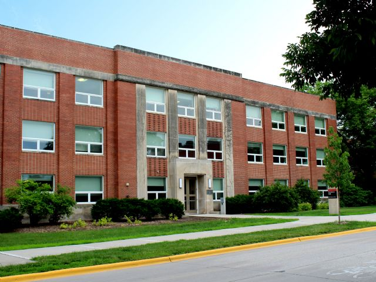

## [Statistics](https://www.stat.iastate.edu/)

Entry-way mural

[figure not shown]

## Main Office - 1121 Snedecor

- Dan Nettleton
  - Department Chair
- Petruța Caragea
  - Associate Chair
- Kathy Kiesling
  - Administrative Assistant II
- Michael Boyd:
  - Graduate Student Services Specialist II

## Additional staff

- Mike Brekke
  - IT Coordinator
  - 2123 Snedecor
- Denise Riker
  - (Undergraduate) Secretary II
  - 3113 Snedecor
- Jill Anderson
  - (Undergraduate) Academic Advisor II
  - 1200 Communication Building

## People

## [Michael Boyd](https://www.stat.iastate.edu/people/michael-boyd) - Graduate Student Services Specialist II

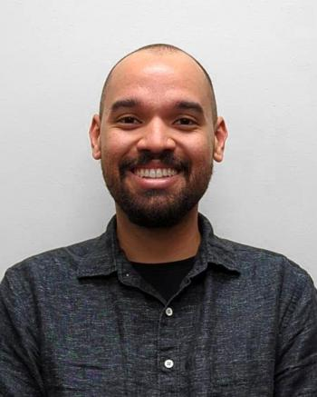

- He can answer all your questions.
- If he can’t, he knows someone who can.

## [Mike Brekke](https://www.stat.iastate.edu/people/michael-brekke) - IT Support

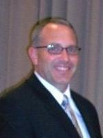

- Computer-related questions
  - Email stat-tech@iastate.edu

## [Petruța Caragea](https://www.stat.iastate.edu/people/petruta-caragea) - Associate Chair

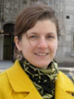

- TA/RA/Teaching Administrative Questions

## [Mark Kaiser](https://www.stat.iastate.edu/people/mark-kaiser) - Outgoing Director of Graduate Studies

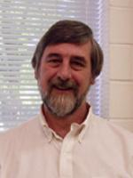

## [Ulrike Genschel](https://www.stat.iastate.edu/people/ulrike-genschel) - Director of Graduate Studies

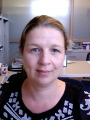

- Your “major professor” when you enter the program
- Ask questions related to the Statistics Program

## [Dan Nettleton](https://www.stat.iastate.edu/people/dan-nettleton) - Department Chair

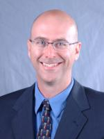

Dan is extremely friendly, but also extremely busy.

## Academics

## [Graduate Program](https://www.stat.iastate.edu/graduate-program)

- [Master of Science in Statistics](https://www.stat.iastate.edu/master-science-requirements)
- [PhD in Statistics](https://www.stat.iastate.edu/phd-requirements)
- [Co-major PhD](https://www.stat.iastate.edu/statistics-co-major-phd-students)
- [MS and PhD minor](https://www.stat.iastate.edu/statistics-minor-phd-students)

## Computing

## [Computing Resources](https://www.stat.iastate.edu/graduate-it-orientation)

- Personal laptop
- Departmental resources
  - pyrite
  - pronto
  - sas.iastate.edu
- [University resources](https://www.hpc.iastate.edu/)
  - condo
  - nova

## [Laptop requirement](https://www.it.las.iastate.edu/student-computer-recommendations)

- Software
  - [R](https://www.r-project.org/) and [RStudio](https://www.rstudio.com/products/rstudio/)
  - [LaTeX](https://www.latex-project.org/)
  - [MS Office](http://office365.iastate.edu/)

## Get Involved

## [STAT-ers](https://www.stat.iastate.edu/isu-stat-ers)

- STAT Graduate Student Organization
- First meeting of the year typically occurs after first departmental seminar
- Various [departmental and student committees](https://www.stuorg.iastate.edu/stat-ers) available

## [STATcom](https://www.stat.iastate.edu/statistics-community)

> StatCom offers statistical advice and expertise free of charge to governmental and nonprofit groups in the local community

## [Research Working Groups](https://www.stat.iastate.edu/working-group-meetings)

- Bayesian
- Causal Inference
- Consulting
- Forensics
- Graphical Statistics
- LunchinatoRs
- Survey

## Communication

## Communication

- MS Teams group
- Email, e.g. statgrad

## File sharing

- File sharing through [CyBox](https://iastate.box.com/)
- T: drive

## Questions?

## Slides online

all orientation slides are available at

https://isustatistics.github.io/grad_orientation/

these slides are available at

https://isustatistics.github.io/grad_orientation/stat.html